# Práctica 2. Tipologia de Datos. Análisis y Visualización

#### * **GLOBULOS ROJOS~CREATININA EN PACIENTES NORMOTENSIONADOS O HIPERTENSOS**

Hacemos lo mismo que en el apartado anterior pero entre globulos rojos y creatinina. Los grupos de estudios son los mismos, pacientes hipertensos y no hipertensos

```r
#Nivel yes: Pacientes con hipertensión
#########
h_yes <- which(datos$htn=="yes")
data_hy=datos[h_yes,]
dim(data_hy)
```

```
## [1] 147  26
```

```r
#Nivel no; Pacientes sin hipertensión
#########
h_no <- which(datos$htn=="no")
data_hn=datos[h_no,]
dim(data_hn)
```

```
## [1] 253  26
```

Obtenemos 147 pacientes con hipertensión y 253 pacientes sin hipertensión. Ahora veámos como afecta la hipertensión a la relación entre glóbulos rojos y creatinina:

```r
model_yes_1<- lm(rc~sc, data=data_hy)
summary(model_yes_1)
```

```
##
## Call:
## lm(formula = rc ~ sc, data = data_hy)
##
## Residuals:
##     Min      1Q  Median      3Q     Max
## -1.6323 -0.3839 -0.0254  0.3242  4.4847
##
## Coefficients:
##             Estimate Std. Error t value Pr(>|t|)
## (Intercept)  4.37163    0.10876  40.197  < 2e-16 ***
## sc          -0.16157    0.02735  -5.907 2.38e-08 ***
## ---
## Signif. codes:  0 '***' 0.001 '**' 0.01 '*' 0.05 '.' 0.1 ' ' 1
##
## Residual standard error: 0.6978 on 145 degrees of freedom
## Multiple R-squared:  0.194,  Adjusted R-squared:  0.1884
## F-statistic: 34.89 on 1 and 145 DF,  p-value: 2.376e-08
```

```r
model_no_1<- lm(rc~sc, data=data_hn)
summary(model_no_1)
```

```
##
## Call:
## lm(formula = rc ~ sc, data = data_hn)
##
## Residuals:
##     Min      1Q  Median      3Q     Max
## -1.6079 -0.5079 -0.1079  0.4921  1.7993
##
## Coefficients:
##             Estimate Std. Error t value Pr(>|t|)
## (Intercept)  5.34376    0.06169  86.625   <2e-16 ***
## sc          -0.27987    0.03029  -9.241   <2e-16 ***
## ---
## Signif. codes:  0 '***' 0.001 '**' 0.01 '*' 0.05 '.' 0.1 ' ' 1
##
## Residual standard error: 0.6932 on 251 degrees of freedom
## Multiple R-squared:  0.2538, Adjusted R-squared:  0.2509
## F-statistic: 85.39 on 1 and 251 DF,  p-value: < 2.2e-16
```

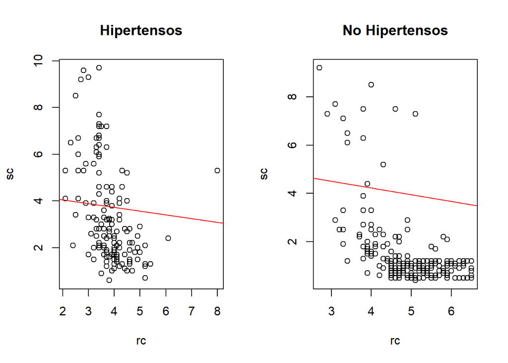

```r
par(mfrow=c(1,2))
plot(data_hy$rc,data_hy$sc,xlab="rc", ylab="sc",main = "Hipertensos")
abline(model_yes_1,col = "red")

plot(data_hn$rc,data_hn$sc,xlab="rc", ylab="sc",main = "No Hipertensos")
abline(model_no_1,col = "red")
```

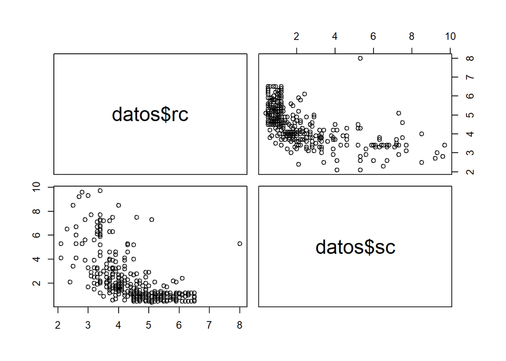

```r
pairs(datos$rc~datos$sc)
```

# *5.-Representación de los resultados mediante gráficas y tablas.*

De entre las representaciones posibles, implementamos los diagramas de cajas de las variables que hemos comparado.

## * **HEMATOCRITO Y HEMOGLOBINA EN DIFERENTES ESTADOS DE NUTRICIÓN**

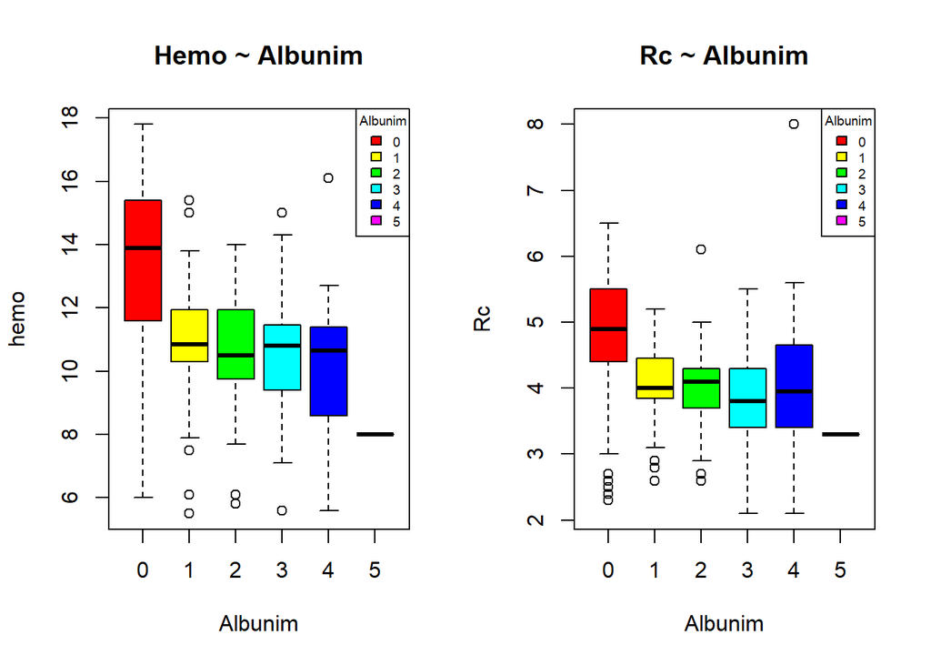

```r
par(mfrow=c(1,2))
boxplot(datos$hemo ~ datos$al,col = rainbow(length(unique(datos$al))),
                          xlab="Albunim", ylab="hemo", main='Hemo ~ Albunim',)

legend("topright", legend=c(0, 1, 2, 3, 4, 5),
       title="Albunim", fill=rainbow(length(unique(datos$al))), cex=0.6, horiz=FALSE)

boxplot(datos$rc ~ datos$al,col = rainbow(length(unique(datos$al))),
                          xlab="Albunim", ylab="Rc", main='Rc ~ Albunim',)

legend("topright", legend=c(0, 1, 2, 3, 4, 5),
       title="Albunim", fill=rainbow(length(unique(datos$al))), cex=0.6, horiz=FALSE)
```

Podemos comprobar las variaciones del hematocrito y el número de glóbulos rojos en relación a los diferentes estados de nutrición del paciente.

## * **HEMATOCRITO Y HEMOGLOBINA EN PACIENTES HIPERTENSOS Y AQUELLOS QUE PRESENTAN UNA TENSIÓN NORMAL**

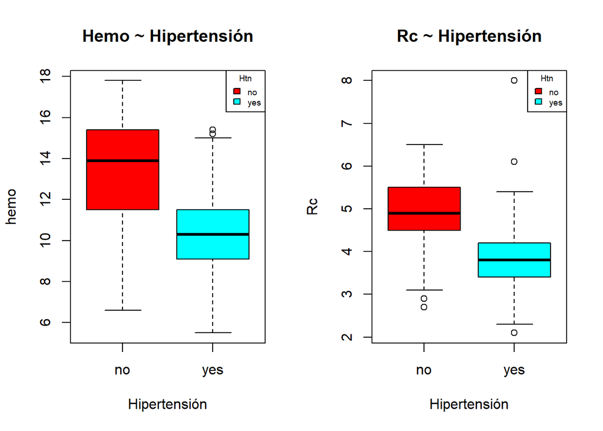

```r
par(mfrow=c(1,2))
boxplot(datos$hemo ~ datos$htn,col = rainbow(length(unique(datos$htn))),
                          xlab="Hipertensión", ylab="hemo", main='Hemo ~ Hipertensión',)

legend("topright", legend=c("no", "yes"),
       title="Htn", fill=rainbow(length(unique(datos$htn))), cex=0.6, horiz=FALSE)

boxplot(datos$rc ~ datos$htn,col = rainbow(length(unique(datos$htn))),
                          xlab="Hipertensión", ylab="Rc", main='Rc ~ Hipertensión',)

legend("topright", legend=c("no", "yes"),
       title="Htn", fill=rainbow(length(unique(datos$htn))), cex=0.6, horiz=FALSE)
```

En general los pacientes hipertensos presentan niveles de hemoglobina y hematocrito peores.

## * **HEMATOCRITO Y CREATININA EN PACIENTES HIPERTENSOS Y AQUELLOS QUE PRESENTAN UNA TENSIÓN NORMAL**

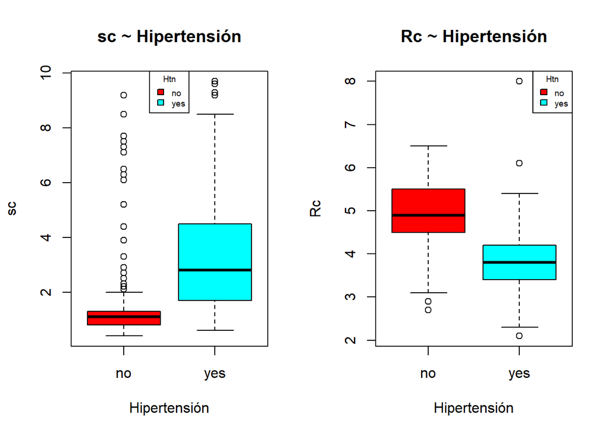

```r
par(mfrow=c(1,2))
boxplot(datos$sc ~ datos$htn,col = rainbow(length(unique(datos$htn))),
                          xlab="Hipertensión", ylab="sc", main='sc ~ Hipertensión',)

legend("top", legend=c("no", "yes"),
       title="Htn", fill=rainbow(length(unique(datos$htn))), cex=0.6, horiz=FALSE)

boxplot(datos$rc ~ datos$htn,col = rainbow(length(unique(datos$htn))),
                          xlab="Hipertensión", ylab="Rc", main='Rc ~ Hipertensión',)

legend("topright", legend=c("no", "yes"),
       title="Htn", fill=rainbow(length(unique(datos$htn))), cex=0.6, horiz=FALSE)
```

Observamos niveles más altos de creatinina en pacientes con hipertensión y como media mayor número de globulos rojos en pacientes normotensionados.

Hemos realizado varios estudios pero vamos a comprobar si tenemos alguna relación entre las variables cuantitativas. Para ello creamos un dataset con solo las variables Cuantitativas:

```r
names<-colnames(datos)
idQuantitative <- which(names=="age"| names=="bp" | names=="bgr"| names=="bu" | names=="sc" | names=="sod" | names=="pot" | names=="hemo" | names=="pcv" | names=="wc"  | names=="rc")

data_Quantitive <- datos[,idQuantitative]
head(data_Quantitive)
```

```
##   age bp bgr bu  sc sod pot hemo pcv   wc  rc
## 1  48 80 121 36 1.2 140 5.0 15.4  44 7800 5.2
## 2   7 50  92 18 0.8 141 4.1 11.3  38 6000 4.7
## 3  62 80 423 53 1.8 134 4.3  9.6  31 7500 4.1
## 4  48 70 117 56 3.8 111 2.5 11.2  32 6700 3.9
## 5  51 80 106 26 1.4 141 4.2 11.6  35 7300 4.6
## 6  60 90  74 25 1.1 142 3.2 12.2  39 7800 4.4
```

## * **CORRELACIONES**

Ahora vamos a visualizar la correlación existente entre las varibles para ver si existe alguna relación entre ellas:

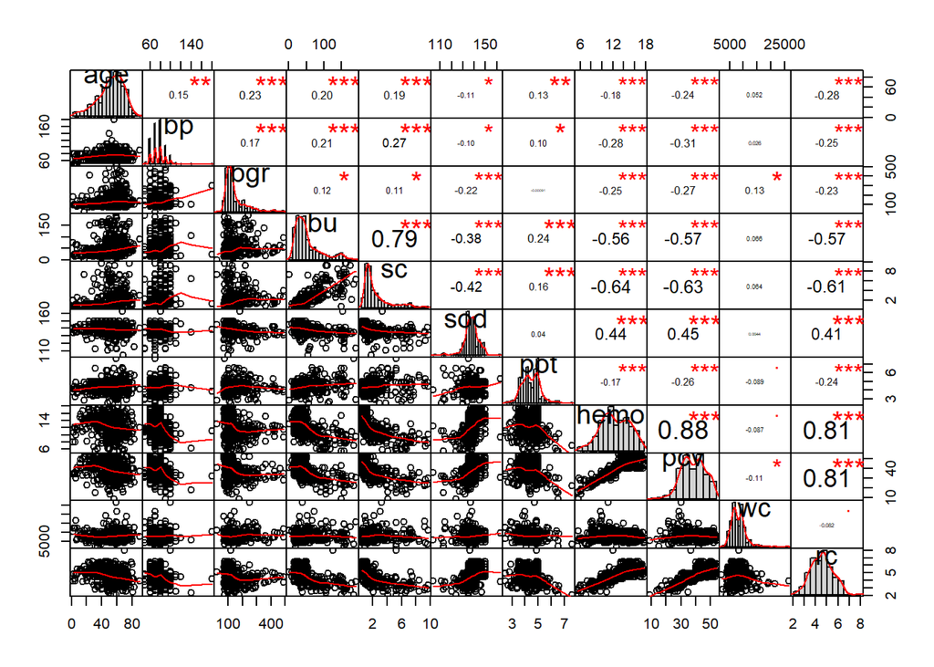

```r
#Vemos la correlación a partir de un gráfico
chart.Correlation(data_Quantitive)
```

Mirando el diagrama vemos que hemo y pcv (es decir, hemoglobina y porcentaje de células) están fuertemente correlacionadas con un valor de correlación de 0.88. Vemos que las dos variables (hemo y pcv) tienen la misma correlación con la variable rc (hematocrito), que tiene valor 0.81. Por otro lado, otra correlación que destaca es la relación entre sc (creatinina) y bu (urea en sangre) correlacionadas con un 0.79. Hay otras correlaciones, aunque no tan superiores puede ser la hemoglobina con la creatinina y la urea, o, estas últimas con los hematocritos.

## * **DIABÉTICOS**

Como afecta la diabétes

Vista la relación entre las variables y vista la relación con la hipertensión, veámos qué pasa con la diabetes.

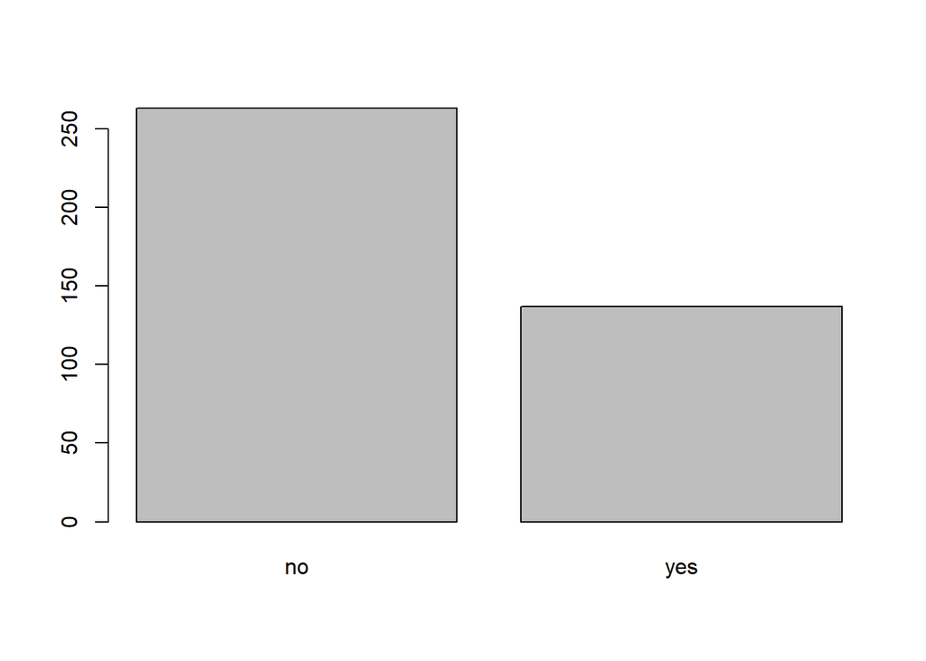

```r
#registos de diabéticos que tenemos en el dataset
barplot(table(datos$dm))
```

```r
table(datos$dm)
```

```
##
##  no yes
## 263 137
```

En la muestra tenemos menos diabéticos que no diabéticos. Tenemos 263 registros no diabéticos frente a 137 sí diabéticos. Casi tenemos el doble de no que de sí.

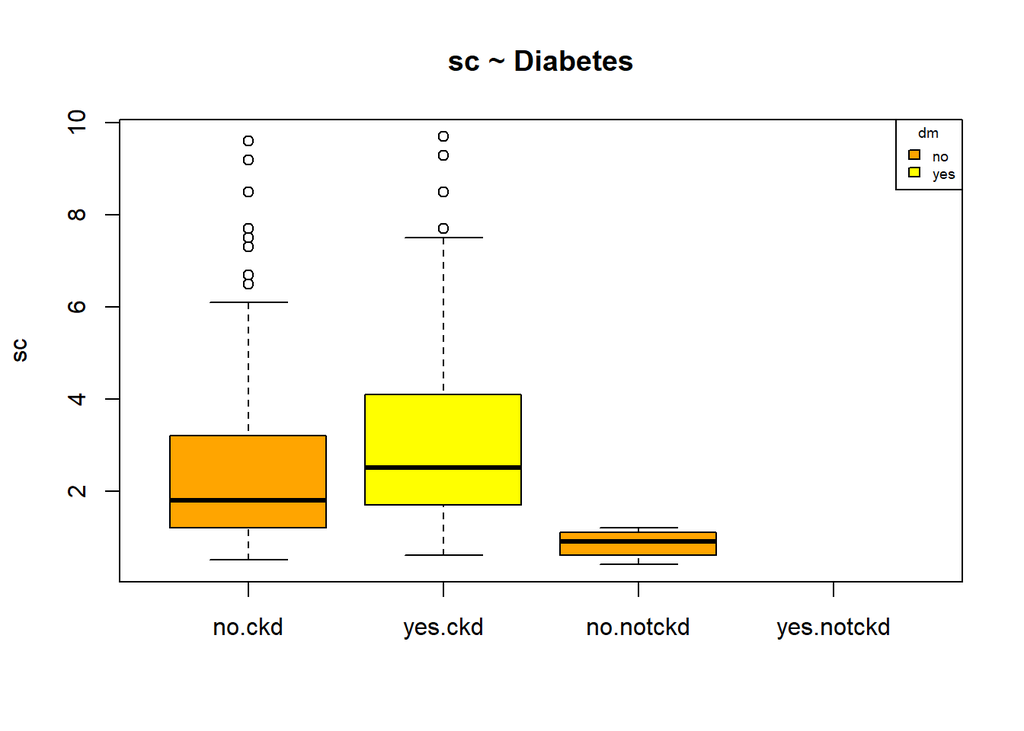

```r
#Creatinina en diabéticos
boxplot(datos$sc ~ datos$dm + datos$classification,col = c("orange", "yellow"),
                          xlab="", ylab="sc", main='sc ~ Diabetes')

legend("topright", legend=c("no", "yes"),
       title="dm", fill=c("orange", "yellow"), cex=0.6, horiz=FALSE)
```

Vemos que los pacientes con la enfermedad crónica pueden ser diabéticos o no. Lo que no ocurre es que, pacientes que no tienen enfermedad en el riñon sean diabéticos. Entonces, en nuestros datos, si eres diabético eres un paciente con enfermedad crónica en el riñón. Observamos que los pacientes enfermos, al sufrir diabetes, tienen la creatinina alterada y algo más superiores que los pacientes no enfermos. De hecho solo por ser pacientes enfermos, ya tiene más alto la creatinina (lo podemos ver si comparamos no.ckd y no.notckd).

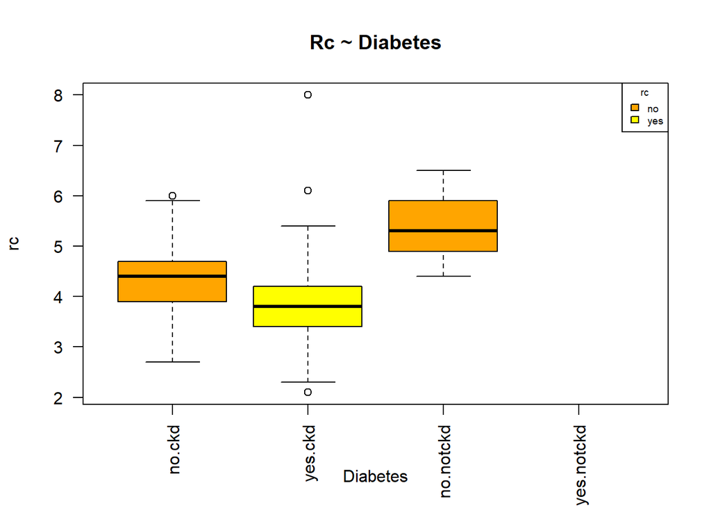

```r
#Hematocritos en Diabéticos
boxplot(datos$rc ~ datos$htn + datos$classification,col = c("orange", "yellow"),
                          xlab="Diabetes", ylab="rc", main='Rc ~ Diabetes', las = 2)

legend("topright", legend=c("no", "yes"),
       title="rc", fill=c("orange", "yellow"), cex=0.6, horiz=FALSE)
```

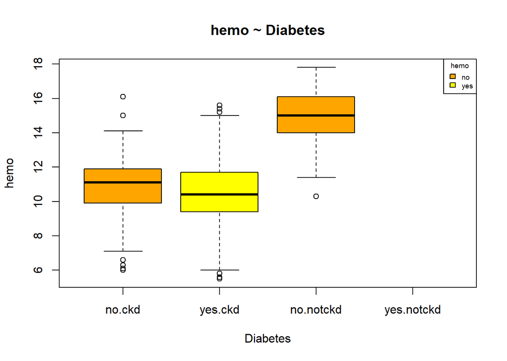

```r
#Hemoglobina en Diabéticos
boxplot(datos$hemo ~ datos$dm + datos$classification, col = c("orange", "yellow"),
                          xlab="Diabetes", ylab="hemo", main='hemo ~ Diabetes',)

legend("topright", legend=c("no", "yes"),
       title="hemo", fill=c("orange", "yellow"), cex=0.6, horiz=FALSE)
```

En este caso vemos que la hemoglobina tiene parámetros muy parecidos entre los pacientes con enfermedad crónica, independientemente de si es diabético o no. Sí tenemos diferencia entre los pacientes no diagnosticados y los diagnosticados, los primeros tiene la hemoglobina más alta que los segundos.

Por supuesto la diabetes es un factor de riesgo para la enfermedad crónica. Independientemente vemos que se puede generar la enfermedad sin ser diabético (ya que los parámetros de diabéticos y no diabéticos en pacientes con enfermedad renal se asemejan mucho).

Un parámetro importante en la detección de la enfermedad es la Albúmina veámos cómo se mueve para pacientes diabéticos. Utilizaremos los grupos generados anteriormente: data_0, data_1, data_2, data_3, data_4 y data_5 para localizare el nivel de albúminia (ya que recordemos que tenemos 6 categorías según el nivel de albúminia):

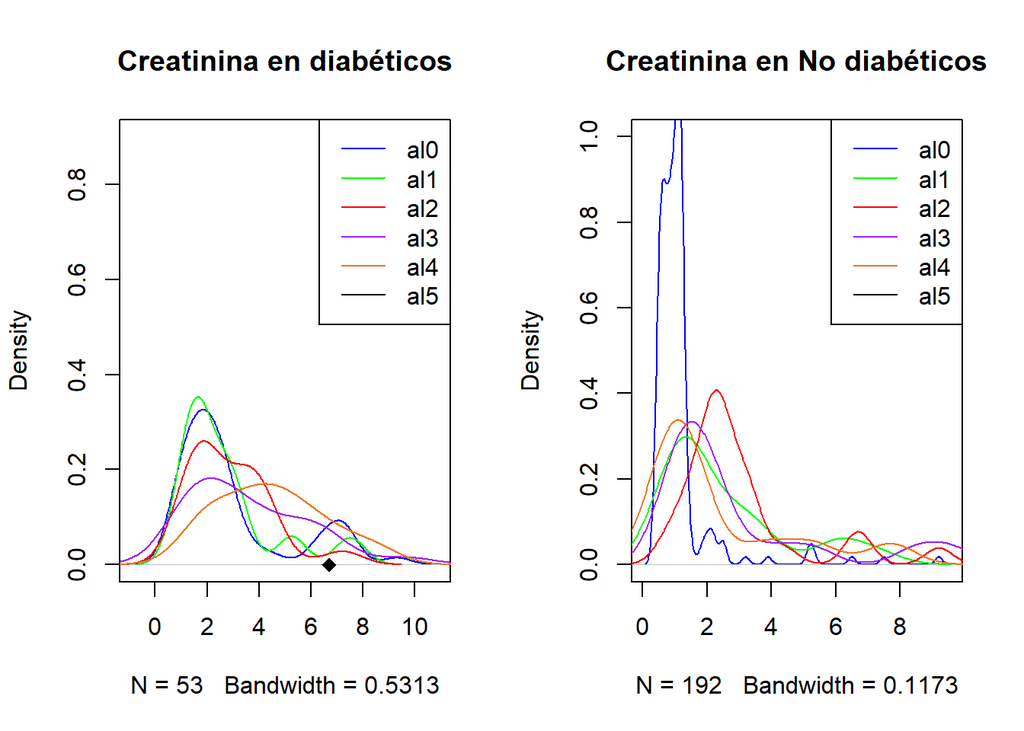

```r
par(mfrow=c(1,2))
#Diagrama densidad en los diferentes niveles de albúminia y siendo diabéticos
plot(density(data_0[data_0$dm=="yes","sc"]), col = "blue", ylim = c(0, 0.9), main ="Creatinina en diabéticos")
lines(density(data_1[data_1$dm=="yes","sc"]), col = "green")
lines(density(data_2[data_2$dm=="yes","sc"]), col = "red")
lines(density(data_3[data_3$dm=="yes","sc"]), col = "purple")
lines(density(data_4[data_4$dm=="yes","sc"]), col = "chocolate2")
points(data_5[data_5$dm=="yes","sc"], 0, col="black", cex=1.3, pch=18)
legend("topright", c("al0", "al1", "al2", "al3", "al4", "al5"),
       lty = 1, col = c("blue", "green", "red", "purple", "chocolate2", "black"))

#Diagrama densidad en los diferentes niveles de albúminia y siendo NO diabéticos
plot(density(data_0[data_0$dm=="no","sc"]), col = "blue", ylim = c(0, 1), main ="Creatinina en No diabéticos")
lines(density(data_1[data_1$dm=="no","sc"]), col = "green")
lines(density(data_2[data_2$dm=="no","sc"]), col = "red")
lines(density(data_3[data_3$dm=="no","sc"]), col = "purple")
lines(density(data_4[data_4$dm=="no","sc"]), col = "chocolate2")
#points(data_5[data_5$dm=="no","sc"], 0, col="black", cex=2, pch=18)  #No tenemos punto con no
legend("topright", c("al0", "al1", "al2", "al3", "al4", "al5"),
       lty = 1, col = c("blue", "green", "red", "purple", "chocolate2", "black"))
```

Podemos ver que la albúminia, en el caso de los diabéticos, se distribuye casi igual en nivel 0 y nivel 1 (hay una pequeña subida entre 6 y 8 para nivel 0). Para el resto de casos cada vez se aplana más. Esto es que, cada vez que la albúminia está en un estadio superior la creatinina toma un rango mayor, aumentado su valor máximo. Así por ejemplo en un estadio 4 de albúminia el rango de la creatinina puede variar entre 0 y 10, obteniendo su mayor densidad alrededor de 4 (mientras que en un estadio 0 estamos alrededor de 2). Por contra partida, si no son diabéticos, la densidad no se aplana aunque tengamos estemos en estadios más altos de albúminia. Tenemos una densidad muy alta en nivel0.

La franja de edad por donde se mueven los diabéticos son:

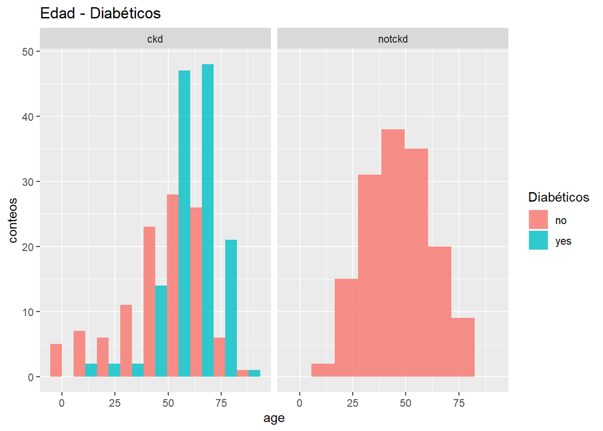

```r
#Gráfica edad diabéticos

ggplot(data = datos,
       mapping = aes(x = age, fill = factor(dm))) +
  geom_histogram(bins = 9, position = 'dodge', alpha = 0.8) +
  labs(title = 'Edad - Diabéticos',
       fill = 'Diabéticos',  x = 'age', y = 'conteos') +
facet_grid(. ~ classification)
```

Nos encontramos diabéticos en casi todas las franjas de edad, pero la franja más afectada es entre los 55 y 70 años, donde los diabéticos se disparan.

## * **ENFERMEDAD CORONARIA**

¿Qué pasa con la enfermedad coronaria?

Igual que hemos hecho con hipertensión y diabetes, veámos ahora esta enfermedad. Veámos si hay alguna relación entre las dos enfermedades respecto a las variables de analítica.

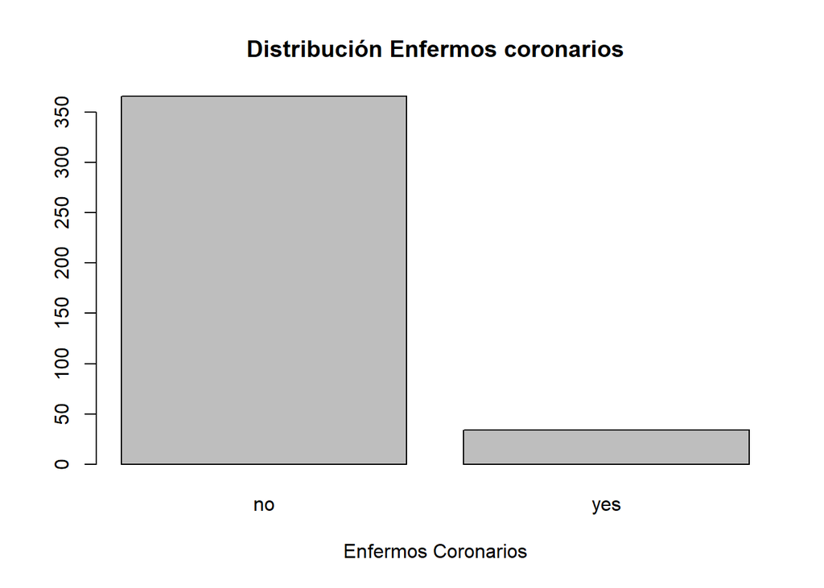

```r
#registos de enfermos coronarios que tenemos en el dataset
barplot(table(datos$cad), main = "Distribución Enfermos coronarios", xlab = "Enfermos Coronarios")
```

```r
table(datos$cad)
```

```
##
##  no yes
## 366  34
```

Tenemos muchísimos más registros que no padecen enfermedad coronaria. De hecho solo la padecen 34 de nuestros pacientes.

La enfermedad coronária puede hacer compotars aumento en la tensión arterial. Veamos de los 34 pacientes que tenemos con enfermedad coronaria cuántos son hipertensos:

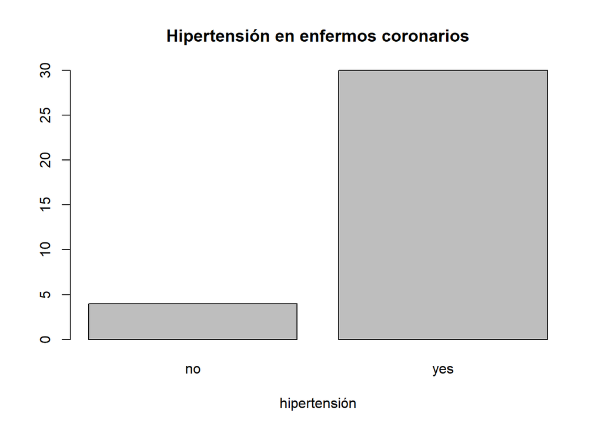

```r
#Diagrama de Hipertensos entre los pacientes que sufren una enfermedad coronaria
barplot(table(datos[datos$cad == "yes", ]$htn), main = "Hipertensión en enfermos coronarios", xlab="hipertensión")
```

```r
#Cantidad
table(datos[datos$cad == "yes", ]$htn)
```

```
##
##  no yes
##   4  30
```

Podemos ver que 30 de los 34 sufren tensión arterial. Segurameente por consecuencia de la enfermedad coronaria.

Veámos ahora cómo tenemos los otros parámetros estudiados dentro de los pacientes con enfermedad coronaria:

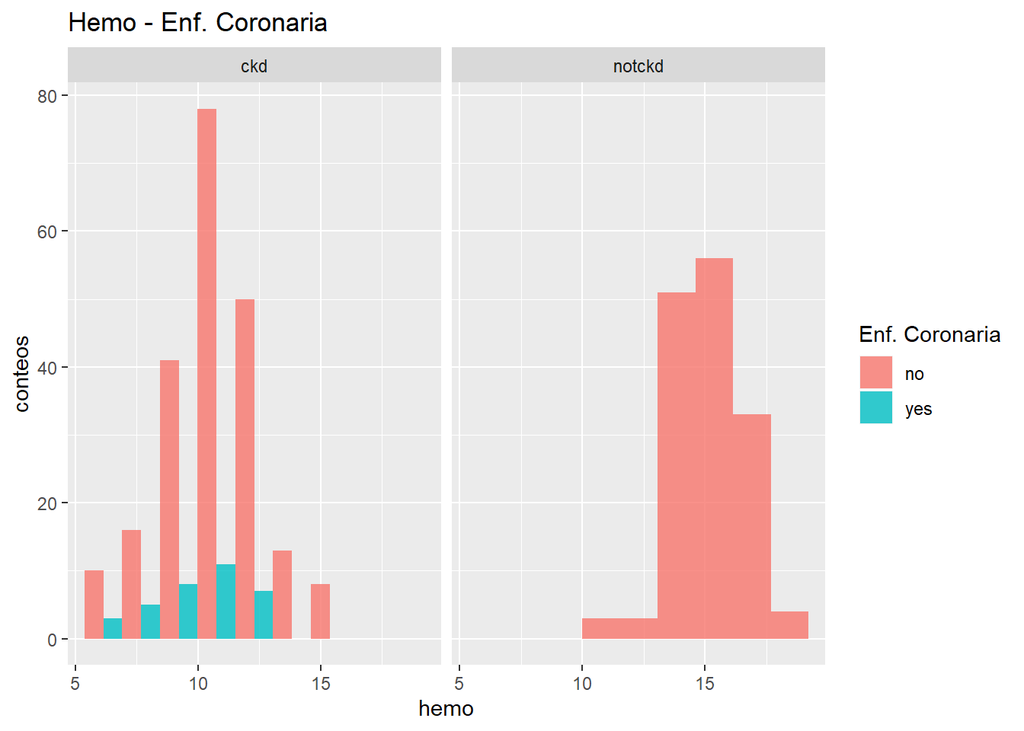

```r
#Gráfico Hemoglobina en enfermedad coronaria
ggplot(data = datos,
       mapping = aes(x = hemo, fill = factor(cad))) +
  geom_histogram(bins = 9, position = 'dodge', alpha = 0.8) +
  labs(title = 'Hemo - Enf. Coronaria',
       fill = 'Enf. Coronaria',  x = 'hemo', y = 'conteos') +
facet_grid(. ~ classification)
```

Podemos ver que los pacientes que sufren una enfermedad coronaria son pocos y su nivel de hemoglobina no llega a 14 mg/ml. Además, en nuestros datos, solo los pacientes con enfermedad crónica tiene enfermedad coronaria.

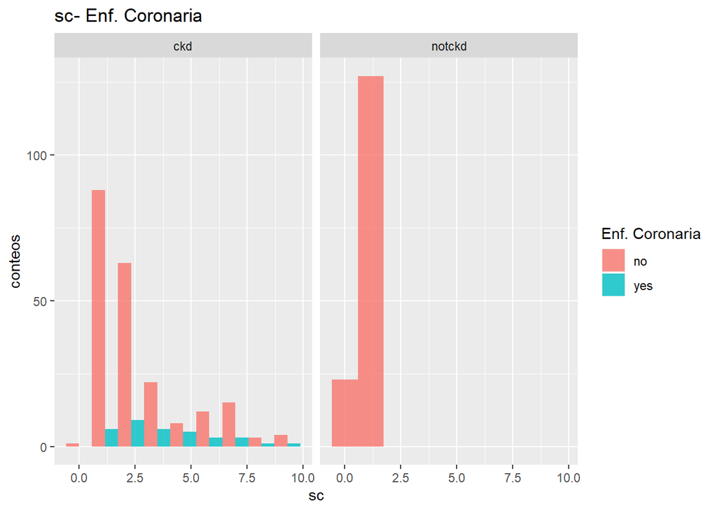

```r
#Gráfico rc en enfermedad coronaria
ggplot(data = datos,
       mapping = aes(x = sc, fill = factor(cad))) +
  geom_histogram(bins = 9, position = 'dodge', alpha = 0.8) +
  labs(title = 'sc- Enf. Coronaria',
       fill = 'Enf. Coronaria',  x = 'sc', y = 'conteos') +
facet_grid(. ~ classification)
```

Nos vuelve a pasar como con la diabetes, que no tenemos ningún registro que, no siendo un paciente crónico, tengan una enfermedad coronaria, En nuestra muestra no tenemos, por tanto, pacientes no crónicos con alguna enfermedad coronaria. Parace que solo se vean afectados los pacientes crónicos. Así, dichos pacientes son los que tiene valores de creatinina. Vemos que tenemos fluctuación en la creatinina, ya sea un paciente con enfermedad coronaria o no. Con enfermedad coronaria tenemos pocos datos y por eso nos aparecen pocos registros (solo tenemos 34).

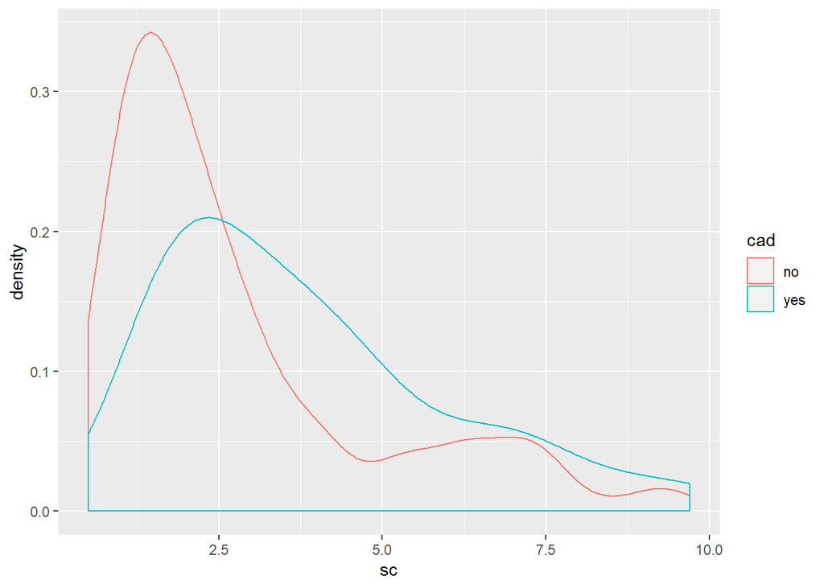

```r
#Gráfica de Creatinina en enfermos crónicos según tengan o no enfermedad coronária
ggplot(datos[datos$classification=="ckd",], aes(x=sc, color=cad)) +
  geom_density()
```

Esta gràfica representamos la parte izquierda de la anterior gráfica, es decir, la evolución de la creatinina en los enfermos crónicos según tengan enfermedad coronaria o no (cad es la variable de enfermedad coronaria). Vemos como la Creatinina es más plana en los enfermos con afectación coronaria, mientras que los que no tienen enfermedad coronaria, su creatinina se mantiene más estable entre el 0 y 2.5.

Vamos a visualizar ahora en qué franja de edad nos movemos entre los pacientes crónicos:

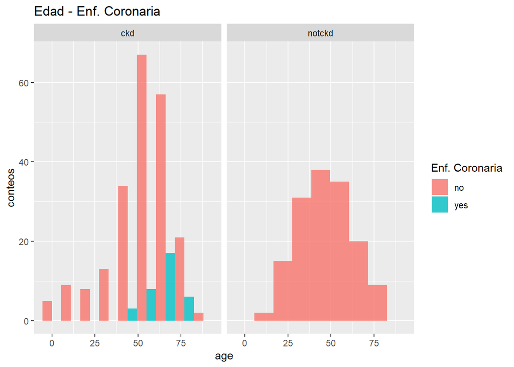

```r
#Gráfica edad en enfermedad coronaria
ggplot(data = datos,
       mapping = aes(x = age, fill = factor(cad))) +
  geom_histogram(bins = 9, position = 'dodge', alpha = 0.8) +
  labs(title = 'Edad - Enf. Coronaria',
       fill = 'Enf. Coronaria',  x = 'age', y = 'conteos') +
facet_grid(. ~ classification)
```

# *6.-Conclusiones.*

Tras el estudio realizado podemos concluir:

Como podemos ver:

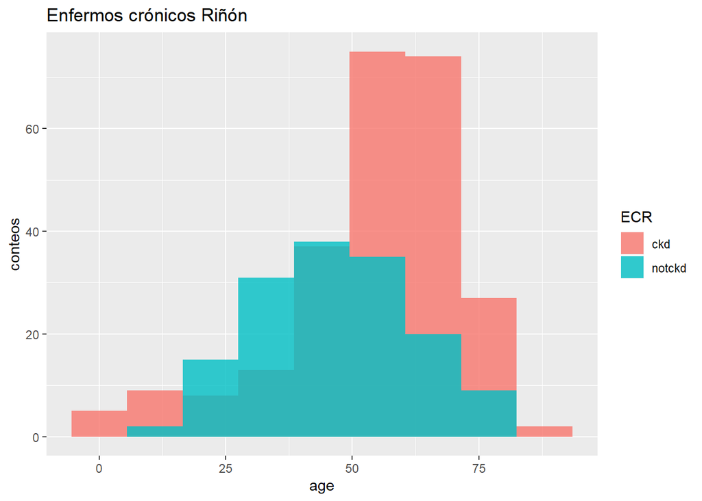

```r
#Gráfica edad en enfermos crónicos
ggplot(data = datos,
       mapping = aes(x = age, fill = factor(classification))) +
  geom_histogram(bins = 9, position = 'identity', alpha = 0.8) +
  labs(title = 'Enfermos crónicos Riñón',
       fill = 'ECR',  x = 'age', y = 'conteos')
```

Entre los 50 y 75 años es donde se mueve el gran volumen de enfermos crónicos del riñón. Como ya hemos observado, a esas la hipertensión, las enfermedades coronarias y la diabetes suelen ser más más frecuentes. Siendo, dichas enfermedades, un factor que favorece un mal funcionamiento de los riñones y por tanto, provocando la enfermedad crónica del riñón.

Resumiendo, los enfermos crónicos padecen creatinina alta, los glóbulos rojos (al igual que los hematocritos), suelen estar bajos:

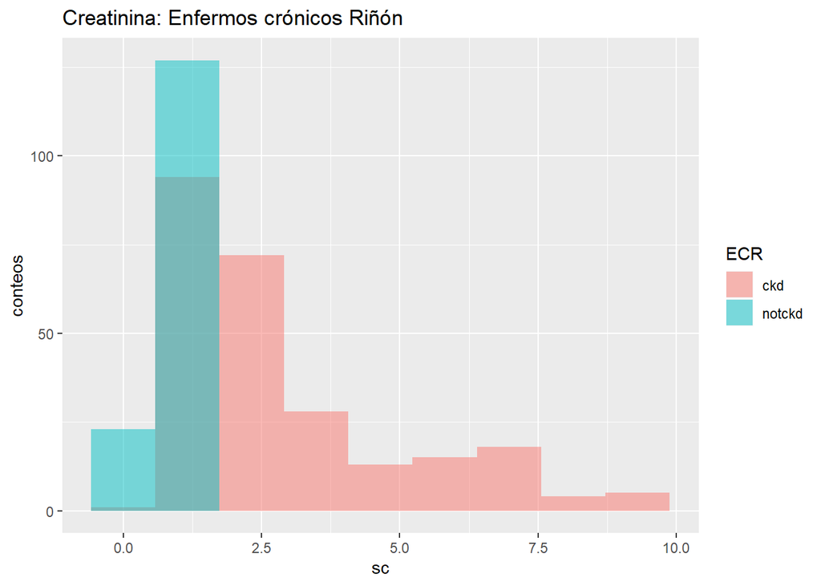

```r
par(mfrow=c(1,2))
#Gráfica edad en enfermos crónicos
ggplot(data = datos,
       mapping = aes(x = sc, fill = factor(classification))) +
  geom_histogram(bins = 9, position = 'identity', alpha = 0.5) +
  labs(title = 'Creatinina: Enfermos crónicos Riñón',
       fill = 'ECR',  x = 'sc', y = 'conteos')
```

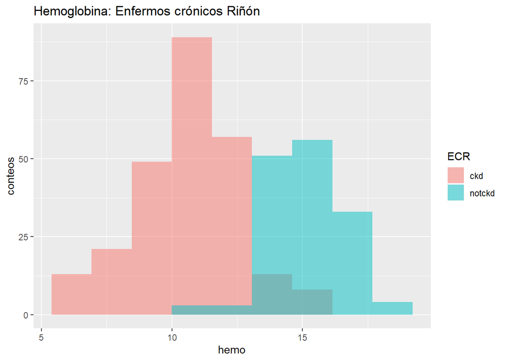

```r
#Gráfica edad en enfermos crónicos
ggplot(data = datos,
       mapping = aes(x = hemo, fill = datos$classification))+
  geom_histogram(bins = 9, position = 'identity', alpha = 0.5) +
  labs(title = 'Hemoglobina: Enfermos crónicos Riñón',
       fill = 'ECR',  x = 'hemo', y = 'conteos')
```

Una alta urea en sangre (a partir de 50 mg) y una alta glucosa en sangre es determinante, ya que parámetros tan altos son indicadores de disfunción renal.

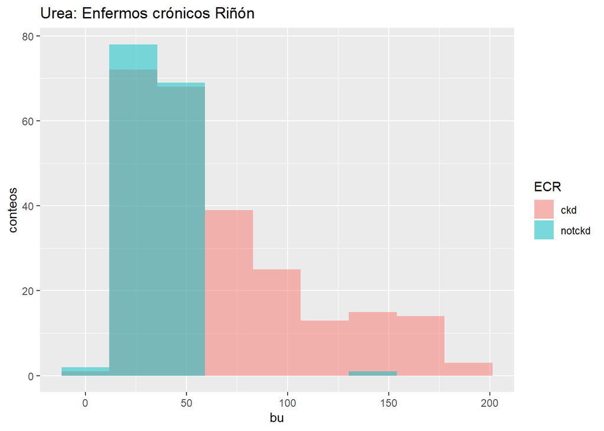

```r
par(mfrow=c(1,2))
#Gráfica edad en enfermos crónicos
ggplot(data = datos,
       mapping = aes(x = bu, fill = factor(classification))) +
  geom_histogram(bins = 9, position = 'identity', alpha = 0.5) +
  labs(title = 'Urea: Enfermos crónicos Riñón',
       fill = 'ECR',  x = 'bu', y = 'conteos')
```

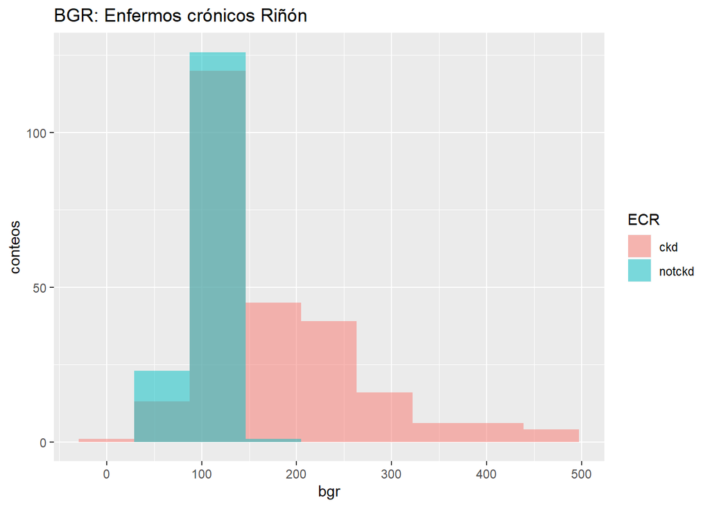

```r
#Gráfica edad en enfermos crónicos
ggplot(data = datos,
       mapping = aes(x = bgr, fill = datos$classification))+
  geom_histogram(bins = 9, position = 'identity', alpha = 0.5) +
  labs(title = 'BGR: Enfermos crónicos Riñón',
       fill = 'ECR',  x = 'bgr', y = 'conteos')
```

La diabetes, la hipertensión, la anemia, la enfermedad cardiaca son enfermedades que pueden ayudar a la aparición de la enfermedad crónica renal. Hay que decir que en estos datos, la mayoría que tienen algún tipo de enfermedad son pacientes diagnosticados de enfermedad crónica renal. Seguramente, el ser un paciente crónico puede hacer desarrollar cualquiera de las otras enfermedades. Independientemente, se hecha en falta tener enfermos de diabetes, hipertensión, anemia, enfermedad cardiaca que no hayan desarrollado la enfermedad crónica y, poder así, obtener un mejor análisis de las variaciaciones de unos y otros. En estas circumstancias, es difícil diagnosticar una enfermedad crónica cuando, como hemos visto, resulta que tenemos resultados tan parecidos sean o no diabéticos, hipertensos o presenten una enfermedad cardiaca.

Como ejemplo de lo explicado, ponemos los gráficos de enfermos cardiacos que padecen o no padencen las enfermedades nombradas. Como se puede observar, tenemos, tanto pacientes con enfermedad como pacientes sin enfermedad mueven en el mismo rango:

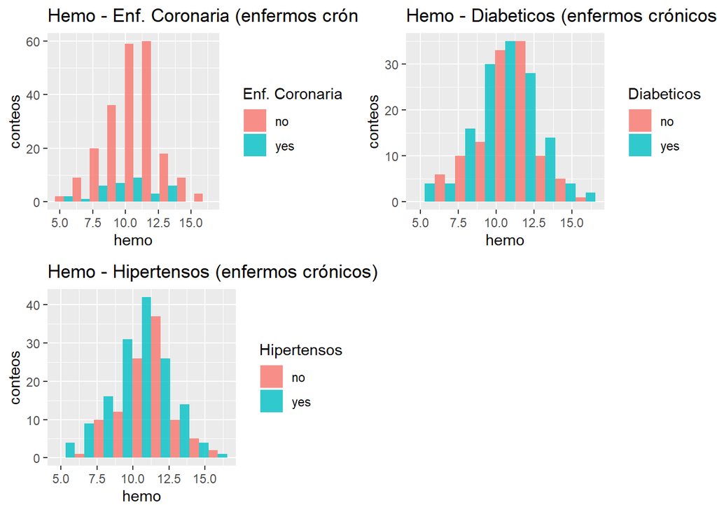

```r
par(mfrow=c(1,3))
#Gráfico Hemoglobina enfermos crónicos con enfermedad coronaria
gg1 <- ggplot(data = datos[datos$classification == 'ckd',],
       mapping = aes(x = hemo, fill = factor(cad))) +
  geom_histogram(bins = 9, position = 'dodge', alpha = 0.8) +
  labs(title = 'Hemo - Enf. Coronaria (enfermos crónicos)',
       fill = 'Enf. Coronaria',  x = 'hemo', y = 'conteos')

#Gráfico Hemoglobina enfermos crónicos con enfermedad coronaria
gg2 <- ggplot(data = datos[datos$classification == 'ckd',],
       mapping = aes(x = hemo, fill = factor(dm))) +
  geom_histogram(bins = 9, position = 'dodge', alpha = 0.8) +
  labs(title = 'Hemo - Diabeticos (enfermos crónicos)',
       fill = 'Diabeticos',  x = 'hemo', y = 'conteos')

#Gráfico Hemoglobina enfermos crónicos con enfermedad coronaria
gg3 <- ggplot(data = datos[datos$classification == 'ckd',],
       mapping = aes(x = hemo, fill = factor(htn))) +
  geom_histogram(bins = 9, position = 'dodge', alpha = 0.8) +
  labs(title = 'Hemo - Hipertensos (enfermos crónicos)',
       fill = 'Hipertensos',  x = 'hemo', y = 'conteos')

grid.arrange(gg1, gg2, gg3,
          ncol = 2, nrow = 2)
```

Como podemos ver, tengan o no tengan la enfermedad los parámetros son muy parecidos en unos u otros, siendo todos pacientes crónicos.